# Diplomatura en BIG DATA

Machine Learning & Data Mining

Escalada Christian, DNI: 33.549.575

10-06-2022

[figure not shown]

# Trabajo Práctico N° 3

## Aprendizaje No Supervisado

$$\\[1in]$$

# 1.1. Abra la base cheddar de la librería faraway.

```r
# Importamos Libreria
library(faraway)

# Cargamos Dataset
data(cheddar)

# Abrimos la base
head(cheddar)
```

```
##   taste Acetic   H2S Lactic
## 1  12.3  4.543 3.135   0.86
## 2  20.9  5.159 5.043   1.53
## 3  39.0  5.366 5.438   1.57
## 4  47.9  5.759 7.496   1.81
## 5   5.6  4.663 3.807   0.99
## 6  25.9  5.697 7.601   1.09
```

## 1.2. Indique de qué tratan cada una de las variables.

- Las variables se tratan acerca de:
  - `Taste`: Es una puntuación de gusto subjetivo.
  - `Acetic`: Es la concentración de ácido acético medido en escala logarítmica.
  - `H2s`: Es la concentración de sulfuro de hidrógeno medido en escala logarítmica.
  - `Lactic`: Es la concentración de ácido láctico.

# 2.1. Muestre un summary de la base.

```r
# Instanciamos Dataset
base = cheddar

# Hacemos Summary
summary(base)
```

```
##      taste           Acetic           H2S             Lactic
##  Min.   : 0.70   Min.   :4.477   Min.   : 2.996   Min.   :0.860
##  1st Qu.:13.55   1st Qu.:5.237   1st Qu.: 3.978   1st Qu.:1.250
##  Median :20.95   Median :5.425   Median : 5.329   Median :1.450
##  Mean   :24.53   Mean   :5.498   Mean   : 5.942   Mean   :1.442
##  3rd Qu.:36.70   3rd Qu.:5.883   3rd Qu.: 7.575   3rd Qu.:1.667
##  Max.   :57.20   Max.   :6.458   Max.   :10.199   Max.   :2.010
```

## 2.2. Considere los 3 últimos dígitos de su DNI para el seteo de la semilla.

- `Además`:
  - Si su DNI termina en 0, 1, 2 ó 3
    - Cantidad de **Grupos** = `3`
  - Si su DNI termina en 4, 5, 6 ó 7
    - Cantidad de **Grupos** = `4`
  - Si su DNI termina en 8 ó 9
    - Cantidad de **Grupos** = `5`
- Mis 3 últimos números de mi DNI son: **575**.
- Mi último número de DNI es **5**.
- La `Cantidad de Grupos` asignado será: **4**.

## 2.3. Realice un agrupamiento kmeans. Indique el código R utilizado.

```r
# Código R Utilizado:
set.seed(575); km=kmeans(cheddar,4)
```

# 3.1 Seleccione 2 variables y realice un gráfico coloreado por los grupos formados.

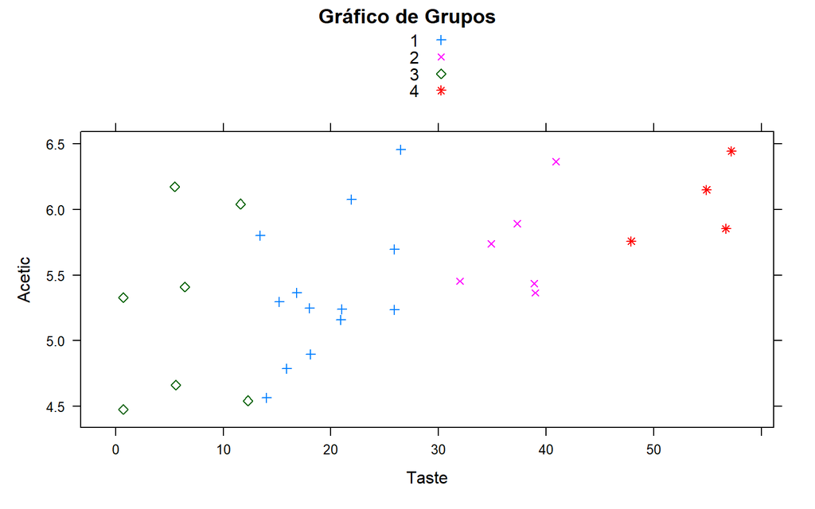

- Las Variables que elegí para realizar el gráfico fueron:
  - `Taste`.
  - `Acetic`.

# 4.1 ¿Cuántos elementos quedaron en cada grupo?

```r
# Verificamos los elementos.
km
```

```
## K-means clustering with 4 clusters of sizes 13, 6, 7, 4
##
## Cluster means:
##       taste   Acetic      H2S   Lactic
## 1 19.500000 5.371692 5.472462 1.380769
## 2 37.166667 5.709333 8.033333 1.618333
## 3  6.114286 5.234571 3.793714 1.194286
## 4 54.175000 6.052750 8.088750 1.810000
##
## Clustering vector:
##  [1] 3 1 2 4 3 1 2 1 1 1 2 4 3 1 4 2 1 3 1 2 1 1 2 4 1 3 1 3 1 3
##
## Within cluster sum of squares by cluster:
## [1] 281.04499  68.90523 134.22596  62.47347
##  (between_SS / total_SS =  93.0 %)
##
## Available components:
##
## [1] "cluster"      "centers"      "totss"        "withinss"     "tot.withinss"
## [6] "betweenss"    "size"         "iter"         "ifault"
```

- Podemos observar que los grupos quedaron conformados por las siguientes cantidades:
  - Grupo N°1: `13` unidades.
  - Grupo N°2: `6` unidades.
  - Grupo N°3: `7` unidades.
  - Grupo N°4: `4` unidades.

# 5.1 Muestre km$cluster.

```r
km$cluster
```

```
##  [1] 3 1 2 4 3 1 2 1 1 1 2 4 3 1 4 2 1 3 1 2 1 1 2 4 1 3 1 3 1 3
```

## 5.2 ¿A qué grupo pertenece el tercer elemento de la base?

- el **Tercer** elemento de la Base pertenece al `Grupo N°2`.

# 6.1 Muestre una captura de pantalla de los Centroides.

```r
# Cargamos Centroides
km$centers
```

```
##       taste   Acetic      H2S   Lactic
## 1 19.500000 5.371692 5.472462 1.380769
## 2 37.166667 5.709333 8.033333 1.618333
## 3  6.114286 5.234571 3.793714 1.194286
## 4 54.175000 6.052750 8.088750 1.810000
```

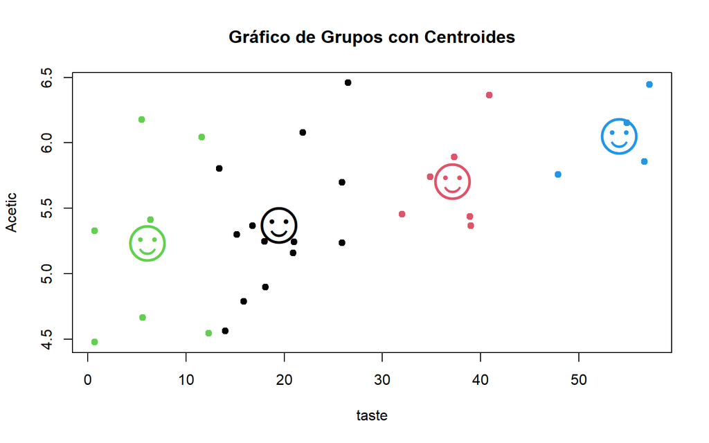

```r
# Mostramos Centroides
attach(base)
plot(taste,Acetic,pch=19,col=km$cluster,main = "Gráfico de Grupos con Centroides")
points(km$centers[,c("taste","Acetic")],pch="☺",col=1:4,cex=4)
```

# 7.1 Determine alguna característica de alguno de los grupos con respecto a los otros grupos.

- `tip`: Analice la información de los Centroides.

```r
# Cargamos Centroides
km$centers
```

```
##       taste   Acetic      H2S   Lactic
## 1 19.500000 5.371692 5.472462 1.380769
## 2 37.166667 5.709333 8.033333 1.618333
## 3  6.114286 5.234571 3.793714 1.194286
## 4 54.175000 6.052750 8.088750 1.810000
```

# Anexo:

## Librerias:

```
library(faraway)
library(caret)
```

## Código:

```
# Importamos Libreria
library(faraway)

# Cargamos Dataset
data(cheddar)

# Abrimos la base
head(cheddar)

# Instanciamos Dataset
base = cheddar

# Hacemos Summary
summary(base)

# Código R Utilizado:
set.seed(575); km=kmeans(cheddar,4)

# Importamos Libreria
library(caret)

# Graficamos
xyplot(base$Acetic~base$taste,base,groups=km$cluster,auto.key=TRUE,
       par.settings=simpleTheme(pch=c(3,4,5,8)),pch=c(3,4,5,8),
       main="Gráfico de Grupos",
       xlab="Taste", ylab="Acetic")

# Verificamos los elementos.
km

# Mostramos cluster
km$cluster

# Mostramos Centroides
attach(base)
plot(taste,Acetic,pch=19,col=km$cluster,main = "Gráfico de Grupos con Centroides")
points(km$centers[,c("taste","Acetic")],pch="☺",col=1:4,cex=4)

# Cargamos los Centroides
km$centers
```

## Bibliografía:

- [plot Function](https://r-coder.com/plot-en-r/#Titulo_del_plot_en_R)
- [Clustering](https://www.etsisi.upm.es/sites/default/files/doctorado/curso_2019_20/material5_jesuslacalle_seminv_2019-20.pdf)
- [R Plot()](https://bookdown.org/jboscomendoza/r-principiantes4/exportar-graficos.html)
- [Pch symbols](http://www.sthda.com/english/wiki/r-plot-pch-symbols-the-different-point-shapes-available-in-r)
- [xyplot()](https://stat.ethz.ch/pipermail/r-help/2009-February/381379.html)
- [Cluster I](https://rpubs.com/lhromeroj/analisisdeclusterR)
- [Cluster II](https://rpubs.com/rdelgado/399475)
- [K-means Wikipedia](https://en.wikipedia.org/wiki/K-means_clustering)
- [Chesse emoji](https://emojipedia.org/cheese-wedge/)

## ¡Muchas Gracias!

[figure not shown]